# Ecologia Numérica - Bases de Dados. Dados do PPBio Semiárido

Exemplos de conjunto de dados ecológicos do Programa de Pesquisa em Biodiversidade (PPBio) do Semiárido

Autores

Prof. Elvio S. F. Medeiros

Laboratório de Ecologia

Universidade Estadual da Paraíba

Campus V, João Pessoa, PB

Data de Publicação

17 de janeiro de 2026

Resumo

Para entender a distribuição das espécies de peixes e seu uso de habitat, uma série de variáveis ambientais foram avaliadas como preditores da composição e riqueza da assembleia de peixes em sistemas aquáticos tropicais semiáridos. Nós pesquisamos a composição de espécies de assembleias de peixes em sistemas aquáticos semiáridos e estabelecemos seu grau de associação com a estrutura do habitat aquático. Os locais consistiam em trechos de riachos com fluxo de água superficial, poças temporárias isoladas e reservatórios artificiais (açudes). A amostragem de peixes foi realizada em quatro ocasiões durante as estações chuvosa (abril e junho de 2006) e seca (setembro e dezembro de 2006).

# 1 Apresentação

Para entender a distribuição das espécies de peixes e seu uso de habitat, uma série de variáveis ambientais foram avaliadas como preditores da composição e riqueza da assembleia de peixes em sistemas aquáticos tropicais semiáridos. Nós pesquisamos a composição de espécies de assembleias de peixes em sistemas aquáticos semiáridos e estabelecemos seu grau de associação com a estrutura do habitat aquático. Os locais consistiam em trechos de riachos com fluxo de água superficial, poças temporárias isoladas e reservatórios artificiais (açudes). A amostragem de peixes foi realizada em quatro ocasiões durante as estações chuvosa (abril e junho de 2006) e seca (setembro e dezembro de 2006).

**Palavras-chave**: rios intermitentes, reservatórios, conservação, composição de substratos.

# 2 Sobre os dados do PPBio

Usaremos ao longo desse livro dados que fazem parte de um estudo mais amplo sobre ecologia de rios do semiárido, coletados no Programa de Pesquisa em Biodiversidade - PPBio (Veja [Programa de Pesquisa em Biodiversidade – PPBio](https://ppbio.inpa.gov.br/Sobre)). Parte desses dados está armazenada em planilhas de Excel `ppbio**.xlsx` (Figura 1). Essas matrizes de dados são descritas na Tabela 1. As planilhas `ppbio**.xlsx` contém vários tipos de dados arranjados em matrizes `n x m` que incluem dados de abundância de espécies em diferentes unidades amostrais (UA’s), dados da estrutura do habitat físico, e variáveis em escala de bacia hidrográfica, dados de contagem de indivíduos ajustados para Captura Por Unidade de Esforço (CPUE), etc (Figura 1).

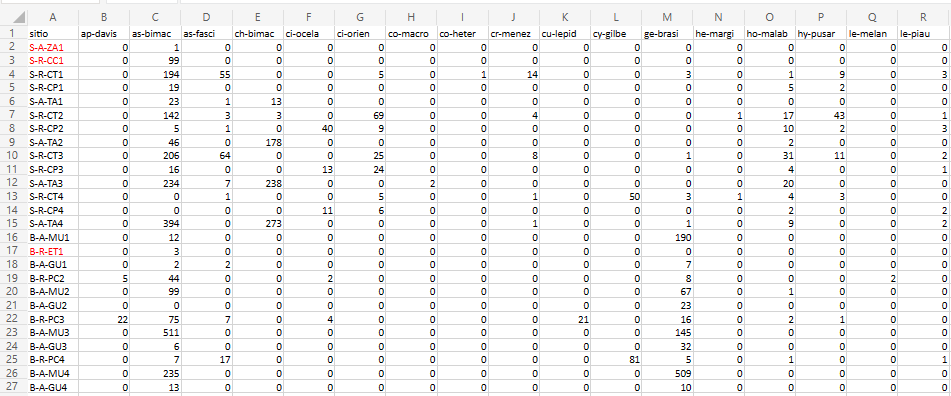

Figura 1: Parte da planilha de dados brutos do PPBio.

Por exemplo, essa é a **matriz bruta de dados**, porque os valores ainda não foram ajustados para os valores de Captura Por Unidade de Esforço (CPUE), nem foram relativizados ou transformados. Outros tipos de arquivos existem sobre esses dados (Tabela 1)).

Várias das espécies nessa matriz tem grande importância ecológica, como é o caso de *Astyanax bimaculatus*[^1] (Figura 2), que é muito comum em rios intermitentes e serve de alimento para predadores maiores (Silva et al. 2018) como a espécie *Hoplias malabaricus*[^2] (Figura 3) (Silva et al. 2010).

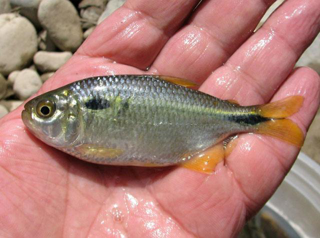

Figura 2: *Astyanax bimaculatus*, a espécie mais comum da matriz de dados ppbio. Peru, by Eakins, R. Fonte: https://www.fishbase.se/summary/Astianax-bimaculatus.html

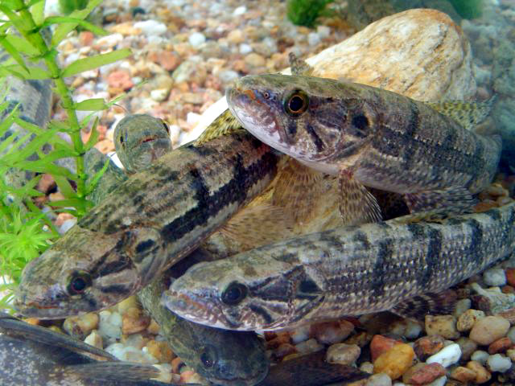

Figura 3: *Hoplias malabaricus*, espécie que cresce para se tornar um importante predador. Brazil, by Roselet, F.F.G. Fonte: https://www.fishbase.se/summary/Hoplias-malabaricus.html

Tabela 1: Matrizes disponíveis para análises, com suas descrições e tipos de dados recomendados.

[output not shown]

```

## Referências

Silva, E. P. da, M. R. N. Duarte, e E. S. F. Medeiros. 2018. [Relação peso-comprimento de duas espécies de peixes em um rio intermitente no nordeste do Brasil](https://doi.org/10.4013/nbc.2018.131.11). Neotropical Biology and Conservation 13.

Silva, M. J., B. R. S. Figueiredo, R. T. C. Ramos, e E. S. F. Medeiros. 2010. Food resources used by three species of fish in the semi-arid region of Brazil. Neotropical Ichthyology 8:825–833.

## Notas de rodapé

[^1]: A etimologia do gênero *Astyanax* vem da mitologia Grega. Heitor personagem da “Ilíada”, tinha um filho chamado Astíanax.
[^2]: Do Grego, *hoplon*, arma ou armadura, em referência aos dentes caniniformes muito desenvolvidos, e forte estrutura óssea na cabeça.